# Introduction to CALMeR

Sowmya Parthiban

# Overview

`CALMeR` (Context-Aware Long-read MAPQ Rescuer) flags reads in long-read transcriptome BAM files whose MAPQ is anomalously low *given* their transcript context. It fits a Beta-Inflated (BEINF) regression model on a sampled subset of reads, computes randomized quantile residuals on the full table, and writes a filtered BAM plus a TSV of flagged reads.

The standard pipeline is six steps; each function is one stage:

1. `extract_features()` — read the BAM + GTF + transcriptome FASTA, build a per-read feature table (MAPQ, alignment length, transcript length, isoform count per gene, GC content, percent transcript covered).
2. `clean_features()` — apply standard pre-fit filters (primary alignments only, n_isoforms cap, GC range, length range).
3. `fit_beinf()` — fit a BEINF regression on a sampled subset.
4. `score_reads()` — compute randomized quantile residuals for every read and flag those whose RQR falls in the lower tail.
5. `filter_bam()` — write a filtered BAM (flagged reads removed) + a TSV of flagged reads with their feature values and residuals.
6. `calmer_report()` — render an HTML or PDF diagnostic report.

# End-to-end pipeline on bundled example data

```r
library(CALMeR)
library(gamlss)   # so pb() resolves in user-supplied formulas

ex <- calmer_example_data()

# Compute the per-transcript paralog status table (cached PAF in the
# bundle; in production this would invoke minimap2 once per annotation).
paralog <- make_paralog_table(
    fasta    = ex$fasta,
    gtf      = ex$gtf,
    paf_path = ex$paf
)

features <- extract_features(ex$bam, ex$gtf, ex$fasta,
                             paralog_table = paralog)
clean    <- clean_features(features)

# pb() smoothers with a coarse 4-knot basis (inter = 4) on the four
# context predictors, plus a linear paralog term. The default pb() basis
# (inter = 20) is too flexible for the ~600-read bundled example and
# produces knot-driven wiggles in the partial-effects panels; a 4-knot
# basis keeps the smoother shape parameteric-like while still allowing
# mild non-linearity. On a real run with tens of thousands of reads,
# drop inter back to its default.
mu_rhs   <- y ~ pb(n_isoforms_sc,  inter = 4) + pb(tx_length_sc,   inter = 4) +
                pb(gc_content_sc,  inter = 4) + pb(pct_covered_sc, inter = 4) +
                max_pct_id_sc
nu_rhs   <-   ~ pb(n_isoforms_sc,  inter = 4) + pb(tx_length_sc,   inter = 4) +
                pb(gc_content_sc,  inter = 4) + pb(pct_covered_sc, inter = 4) +
                max_pct_id_sc

fit <- fit_beinf(
    clean, n = nrow(clean),
    predictors    = c("n_isoforms", "tx_length", "gc_content",
                      "pct_covered", "max_pct_id"),
    formula       = mu_rhs,
    sigma_formula = ~ 1,
    nu_formula    = nu_rhs,
    tau_formula   = nu_rhs
)

scored <- score_reads(features, fit, filter_method = "mad",
                      threshold = -3)
```

```
#> score_reads: 14 reads have n_isoforms outside training range [1, 10]; marking unscored.
#> score_reads: 5 reads have tx_length outside training range [200, 7967]; marking unscored.
```

# Filtered outputs

`filter_bam()` writes a filtered BAM (flagged reads removed) and a gzipped TSV listing the flagged reads with their feature values and residuals. Internal scaled-predictor columns (`*_sc`) are dropped from the TSV — the file keeps the columns a user would actually inspect.

```r
filt <- filter_bam(
    bam     = ex$bam,
    scored  = scored,
    out_bam = tempfile(fileext = ".bam"),
    out_tsv = tempfile(fileext = ".tsv.gz")
)
```

```
#> filter_bam: 628 alignments in, 2 flagged reads (2 alignments removed), 626 alignments kept.
```

```r
filt$out_tsv
```

```
#> [1] "/var/folders/f8/x74ffsss03zc0bgrk_xg9_dw0000gn/T//RtmpIJPPIB/filed26860163e62.tsv.gz"
```

Flagged reads (2 total, all 23 columns shown — scroll horizontally).

| read_id | transcript_id | MAPQ | alignment_length | aln_type | tx_length | n_exons | n_isoforms | gc_content | pct_covered | max_pct_id | n_cross_hits | has_paralog_50 | has_paralog_80 | has_paralog_90 | has_paralog_95 | mu_p | sigma_p | nu_p | tau_p | rqr | flag_low | out_of_range |
| --- | --- | --- | --- | --- | --- | --- | --- | --- | --- | --- | --- | --- | --- | --- | --- | --- | --- | --- | --- | --- | --- | --- |
| SRR30947471.26882017 | ENST00000231512.5 | 0 | 2219 | P | 2188 | 3 | 1 | 37.52285 | 100.00000 | 0 | 0 | FALSE | FALSE | FALSE | FALSE | 0.4742353 | 0.5690369 | 0.1177081 | 10.8304600 | -3.782351 | TRUE | FALSE |
| SRR30947471.27503043 | ENST00000313115.11 | 0 | 414 | P | 471 | 4 | 4 | 56.68790 | 87.89809 | 0 | 0 | FALSE | FALSE | FALSE | FALSE | 0.4823948 | 0.5690369 | 0.2614457 | 0.2029714 | -3.449902 | TRUE | FALSE |

# Diagnostic report (rendered inline)

The chunk below pulls in `inst/rmd/diagnostic_report.Rmd` as a child document and renders it inline as part of this vignette. All sections of the standalone report — predictor definitions, training summary, model fit, model comparison, residual diagnostics, partial effects, scoring summary, where flags landed — appear below.

# Predictors

CALMeR conditions MAPQ on the following per-read / per-transcript features. Default `clean_features()` filters are listed alongside; ranges shown in the partial-effects plots may be tighter (e.g. `n_isoforms` is capped at 7 in the partial-effect panel for visual clarity).

| Predictor | What it measures | How it’s computed | Default `clean_features()` filter |
| --- | --- | --- | --- |
| `n_isoforms` | Number of annotated isoforms of the **gene** that the read’s target transcript belongs to. | `n_distinct(transcript_id)` per `gene_id`, from the GTF. | `<= 10` |
| `tx_length` | Length of the target transcript in nucleotides. | Sum of exon widths per `transcript_id`, from the GTF. | `[100, 10000]` bp |
| `gc_content` | GC composition of the target transcript. | `(G + C) / length` from the transcriptome FASTA. | `[30, 70]%` |
| `pct_covered` | Fraction of the target transcript spanned by the read alignment. | `min(alignment_length / tx_length, 1)`, from the BAM CIGAR + GTF. | none (uses full 0-100% range) |
| `max_pct_id` *(if present)* | Highest cross-gene transcript-level identity for the target. Captures paralog ambiguity. | `minimap2` self-alignment of the transcriptome FASTA, then `max(pct_id)` over hits with `alen >= 50` and `query_cov >= 70%`, restricted to cross-gene pairs. | none (raw 0-100%; 0 = no paralog) |

The partial-effects plot caps `n_isoforms` at **7** for the x-axis even when training data extends higher, since most of the predictive content sits in the 1-7 range and very high values become sparse.

# 1. Training summary

The model was fit on 609 reads sampled from primary alignments. Predictors used: n_isoforms, tx_length, gc_content, pct_covered, max_pct_id.

Predictor distributions on the training data.

| predictor | min | median | max | sd |
| --- | --- | --- | --- | --- |
| n_isoforms | 1.00 | 2.00 | 10.00 | 1.98 |
| tx_length | 200.00 | 1044.00 | 7967.00 | 1250.41 |
| gc_content | 34.56 | 49.47 | 66.89 | 6.67 |
| pct_covered | 3.18 | 85.01 | 100.00 | 31.96 |
| max_pct_id | 0.00 | 0.00 | 100.00 | 31.35 |

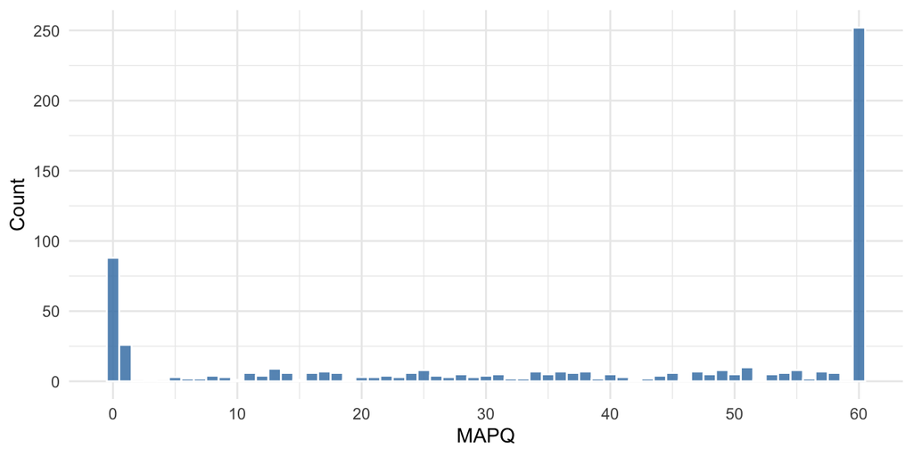

Observed MAPQ distribution on training data.

# 2. Model fit

**Formulas used:**

- $\mu$: `y ~ pb(n_isoforms_sc, inter = 4) + pb(tx_length_sc, inter = 4) + pb(gc_content_sc, inter = 4) + pb(pct_covered_sc, inter = 4) + max_pct_id_sc`
- $\sigma$: `~1`
- $\nu$: `~pb(n_isoforms_sc, inter = 4) + pb(tx_length_sc, inter = 4) + pb(gc_content_sc, inter = 4) + pb(pct_covered_sc, inter = 4) + max_pct_id_sc`
- $\tau$: `~pb(n_isoforms_sc, inter = 4) + pb(tx_length_sc, inter = 4) + pb(gc_content_sc, inter = 4) + pb(pct_covered_sc, inter = 4) + max_pct_id_sc`

Effective degrees of freedom for each smooth term.

| parameter | term | edf |
| --- | --- | --- |
| mu | n_isoforms_sc | 2.00 |
| mu | tx_length_sc | 3.02 |
| mu | gc_content_sc | 3.39 |
| mu | pct_covered_sc | 2.00 |
| nu | n_isoforms_sc | 2.00 |
| nu | tx_length_sc | 2.00 |
| nu | gc_content_sc | 2.79 |
| nu | pct_covered_sc | 2.00 |
| tau | n_isoforms_sc | 4.06 |
| tau | tx_length_sc | 2.00 |
| tau | gc_content_sc | 2.00 |
| tau | pct_covered_sc | 2.65 |

**Pseudo-$R^2$:** 0.4269

# 2b. Model comparison

Model fit metrics on the training data. Lower AIC/BIC and higher pseudo-$R^2$ are better.

| Model | AIC | BIC | df | Pseudo R^2 |
| --- | --- | --- | --- | --- |
| User-supplied | 934.3 | 1044.1 | 24.9 | 0.4269 |
| All linear (5 predictors) | 968.3 | 1052.2 | 19.0 | 0.3821 |
| All linear (no max_pct_id) | 997.1 | 1067.7 | 16.0 | 0.3458 |
| pb on 4 non-paralog + linear max_pct_id | 931.8 | 1051.2 | 27.1 | 0.4333 |

# 3. Residual diagnostics

Randomized quantile residuals (RQR) should be approximately $N(0, 1)$ under a correctly specified BEINF model.

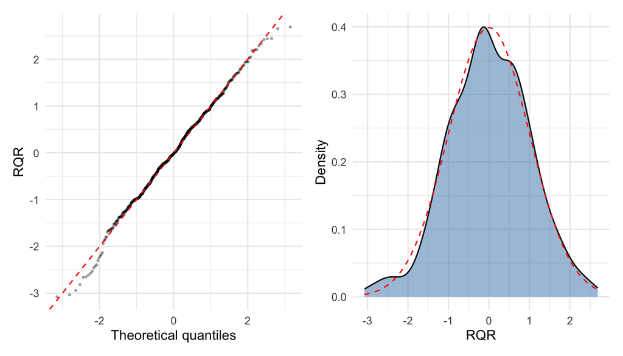

Global QQ plot (left) and density vs N(0, 1) (right).

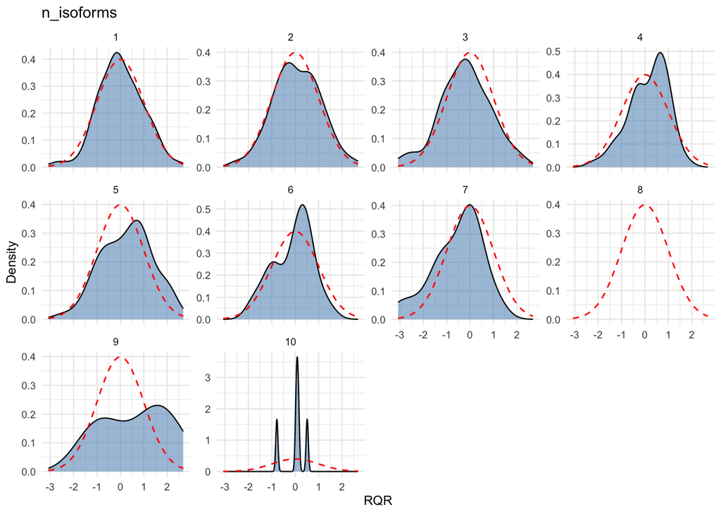

RQR density faceted by predictor bins, with N(0, 1) reference (red dashed).

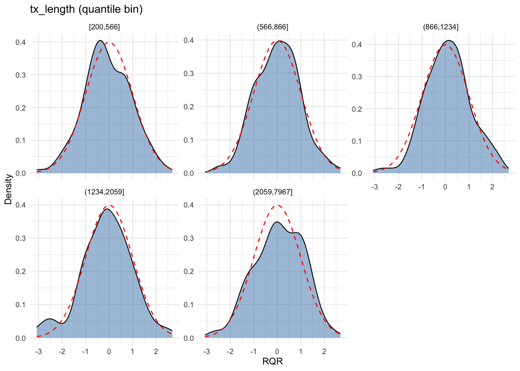

RQR density faceted by predictor bins, with N(0, 1) reference (red dashed).

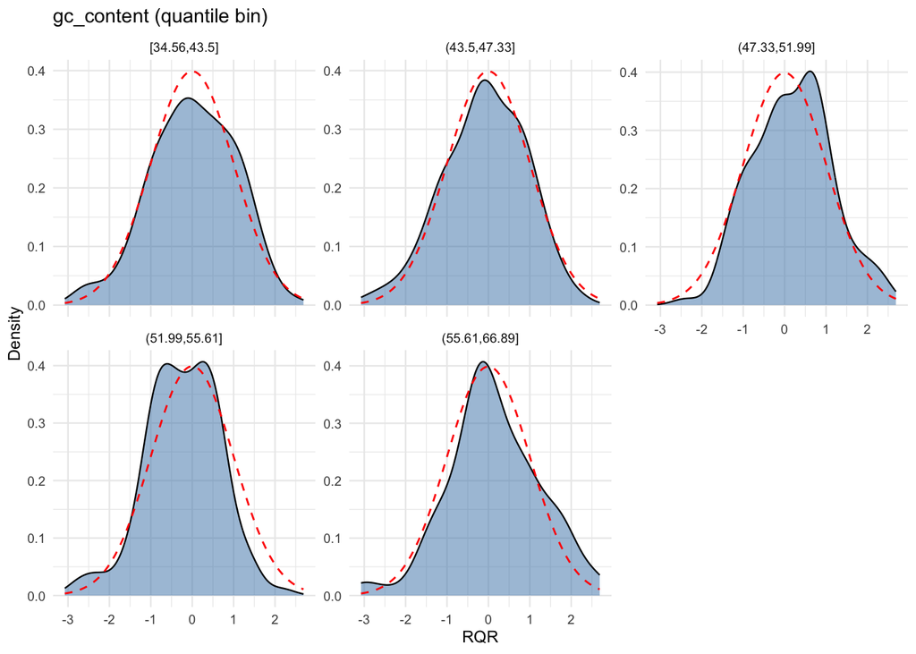

RQR density faceted by predictor bins, with N(0, 1) reference (red dashed).

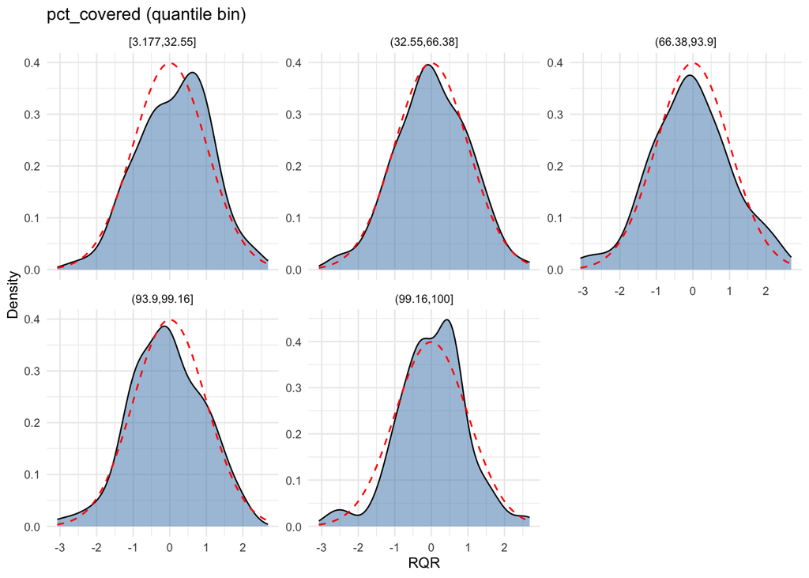

RQR density faceted by predictor bins, with N(0, 1) reference (red dashed).

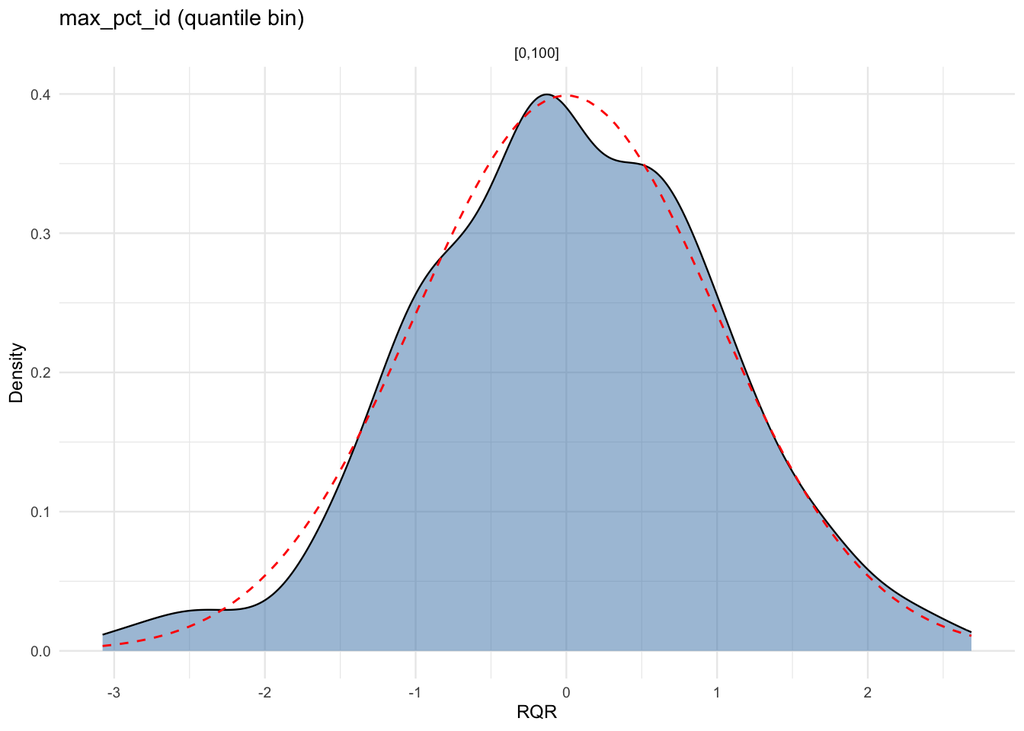

RQR density faceted by predictor bins, with N(0, 1) reference (red dashed).

# 4. Partial effects on E[MAPQ]

Each panel varies one predictor over its training range while holding the others at their training median, and shows the model’s expected MAPQ:

$$E[Y] \;=\; \frac{\tau + \mu}{1 + \nu + \tau}, \qquad
E[\mathrm{MAPQ}] = 60 \cdot E[Y]$$

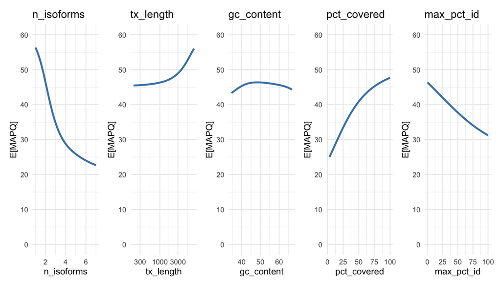

Partial effects on E[MAPQ].

# 5. Scoring summary

- Filter method: **mad**
- Threshold: **-3**
- Residual cut: RQR < -3.009
- Reads scored: 609 / 628
- Reads flagged: 2 (0.33% of scored)

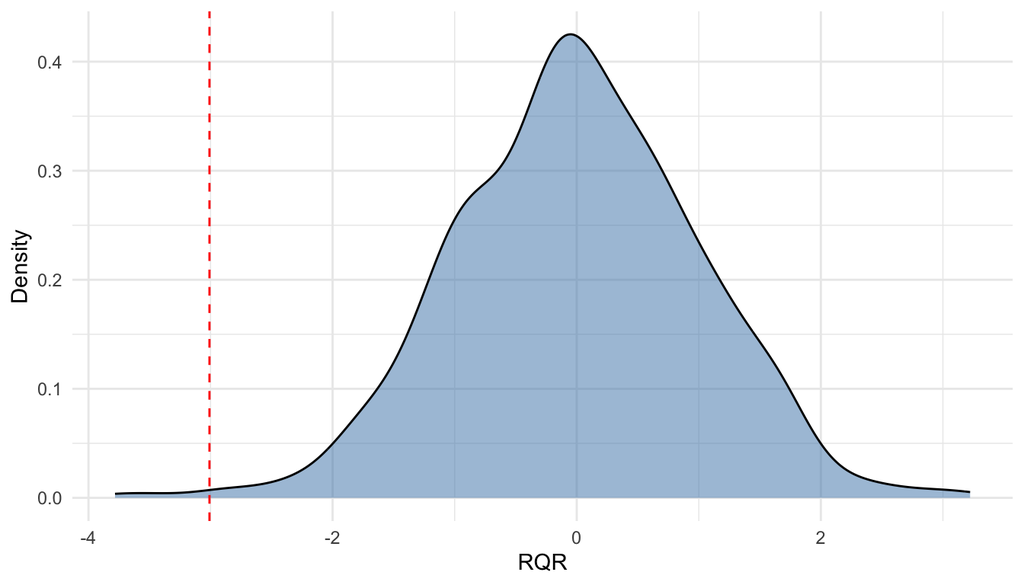

RQR distribution on scored reads with flag threshold (red dashed).

# 6. Where flags landed

Per n_isoforms: scored count, flagged count, % flagged, and group-level context (median tx_length, median gc_content, % of reads on transcripts with a paralog at >50% identity).

| n_isoforms | n_scored | n_flagged | pct_flagged | median_tx_length | median_gc_content | pct_paralog_gt50 |
| --- | --- | --- | --- | --- | --- | --- |
| 1 | 184 | 1 | 0.54 | 933 | 48.3 | 10.9 |
| 2 | 144 | 0 | 0.00 | 921 | 50.2 | 18.8 |
| 3 | 97 | 0 | 0.00 | 1129 | 50.0 | 3.1 |
| 4 | 55 | 1 | 1.82 | 1127 | 47.6 | 12.7 |
| 5 | 52 | 0 | 0.00 | 1069 | 49.9 | 1.9 |
| 6 | 42 | 0 | 0.00 | 1096 | 53.0 | 23.8 |
| 7 | 22 | 0 | 0.00 | 2036 | 46.8 | 9.1 |
| 8 | 1 | 0 | 0.00 | 4765 | 45.0 | 0.0 |
| 9 | 7 | 0 | 0.00 | 1977 | 55.7 | 0.0 |
| 10 | 5 | 0 | 0.00 | 1931 | 55.5 | 0.0 |

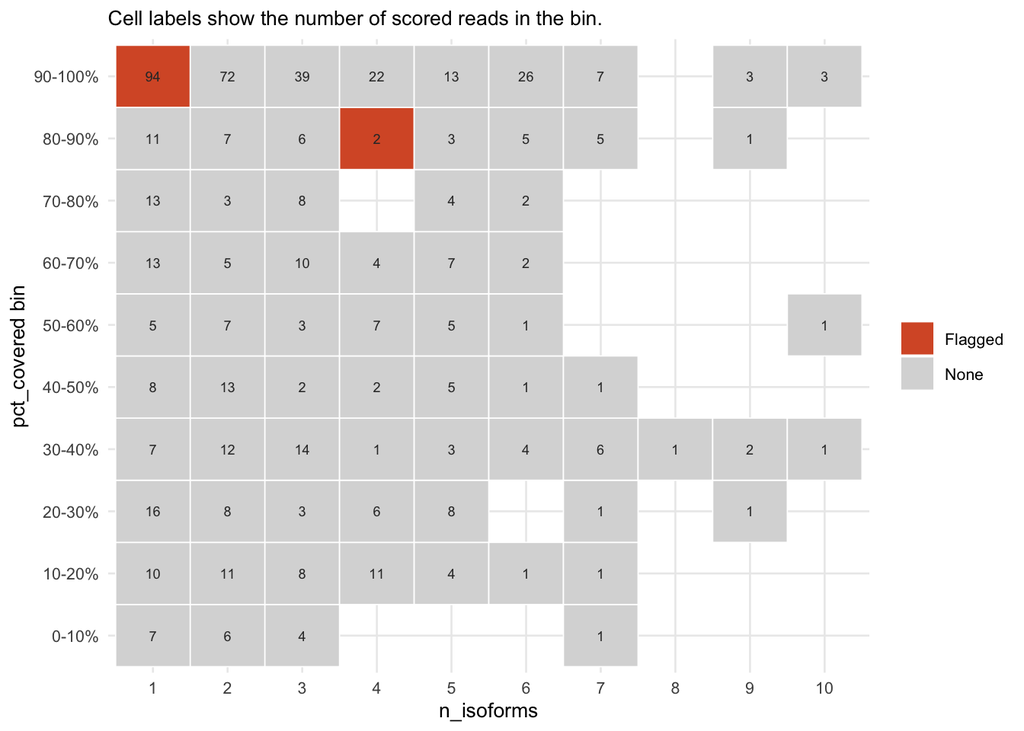

Any flag in cell (orange) vs. none (grey), by n_isoforms x pct_covered bin.

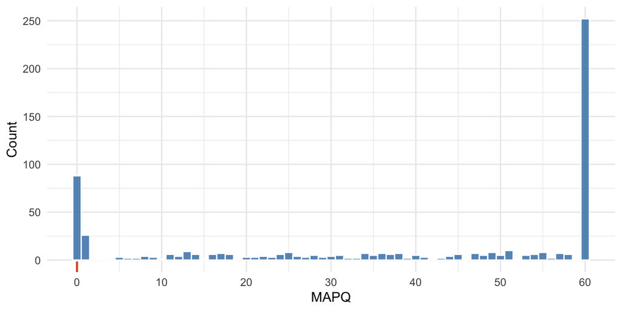

Scored MAPQ distribution. Red rug ticks mark MAPQ values of the flagged reads.